# MD7

```r
library(tidyverse)
library(here)
library(moderndive)
library(readr)
library(tibble)
```

```r
library(readr)
nobel_winners <- read_csv("https://raw.githubusercontent.com/vaiseys/dav-course/main/Data/nobel_winners.csv")
```

```r
nobel_winners_flt <- nobel_winners %>%
  filter(category != "Peace") %>%
  mutate(is_us = if_else(birth_country == "United States of America", 1, 0))
```

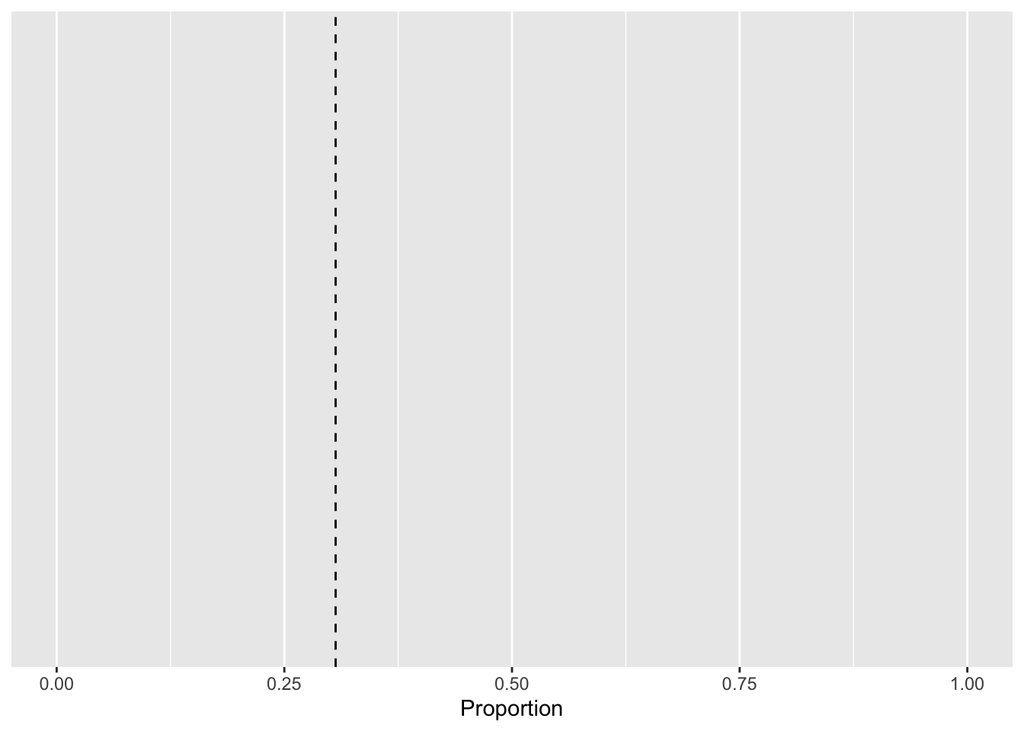

```r
true_prop <- nobel_winners_flt %>%
  group_by(is_us) %>%
  summarise(prop = n()/nrow(nobel_winners_flt))

ggplot() +
  coord_cartesian(xlim = c(0,1), ylim = c(0,1)) +
  geom_vline(xintercept = true_prop[2,2][[1]], linetype = "dashed")  +
  labs(x = "Proportion")
```

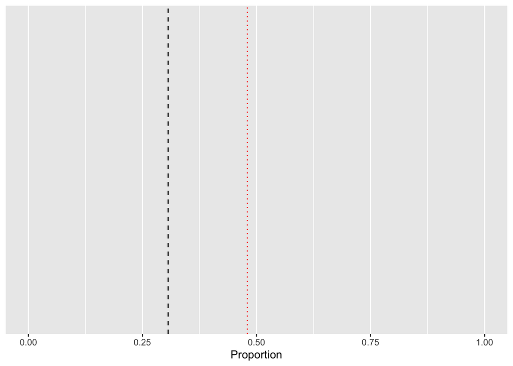

```r
set.seed(33)
# Random sample
our_sample <- sample_n(nobel_winners_flt,
                       size = 25,
                       replace = F)

sample_prop <- our_sample %>%
  group_by(is_us) %>%
  summarise(prop = n()/nrow(our_sample))

# How does our proportion look like?
ggplot() +
  coord_cartesian(xlim = c(0,1), ylim = c(0,1)) +
  geom_vline(xintercept = true_prop[2,2][[1]], linetype = "dashed")  +
  geom_vline(xintercept = sample_prop[2,2][[1]], linetype = "dotted", col = "red") +
  labs(x = "Proportion")
```

Q.1)

Q: In this scenario, what is the population?

Q.2)

```r
nobel_25 <- nobel_winners_flt %>%
  rep_sample_n(size = 25, reps = 50) %>%
  group_by(replicate) %>%
  summarise(prop = sum(is_us)/25)
```

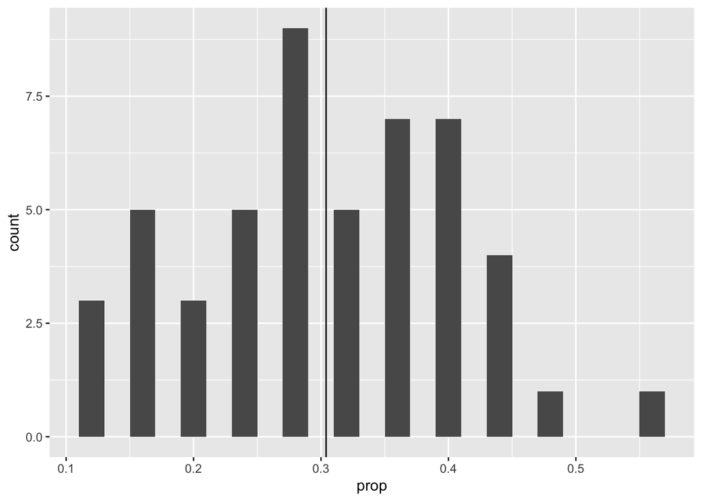

```r
ggplot(nobel_25,
      aes(x = prop)) +
  geom_histogram(binwidth = .02) +
  geom_vline(aes(xintercept = mean(prop)))
```

Q.3)

```r
nobel_100 <- nobel_winners_flt %>%
  rep_sample_n(size = 100, reps = 50) %>%
  group_by(replicate) %>%
  summarise(prop = sum(is_us)/100)
```

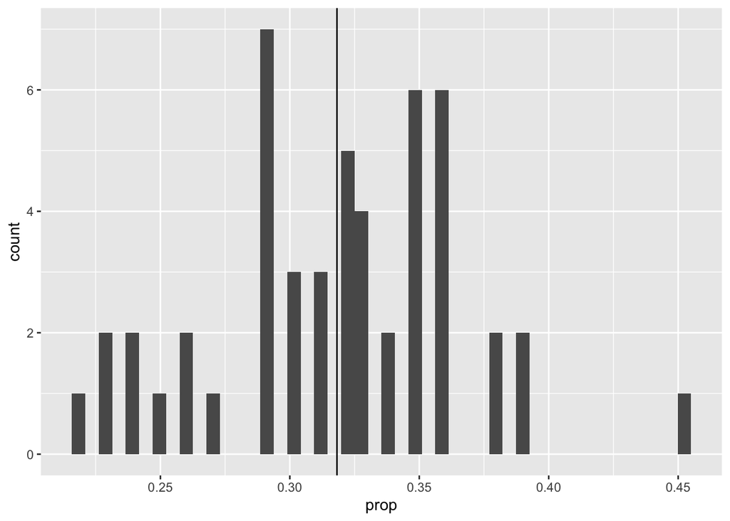

```r
ggplot(nobel_100,
      aes(x = prop)) +
  geom_histogram(binwidth = .0052) +
  geom_vline(aes(xintercept = mean(prop)))
```

Q.4)

```r
sd_nobel_25 <- nobel_winners_flt %>%
  rep_sample_n(size = 25, reps = 50) %>%
  summarise(prop = n()/nrow(nobel_winners_flt))
```

```r
sd_nobel_100 <- nobel_winners_flt %>%
  rep_sample_n(size = 100, reps = 50) %>%
  summarise(prop = n()/nrow(nobel_winners_flt))
```

```r
sd_nobel_25 %>%
  summarise(sd = sd(prop))
```

```
# A tibble: 1 × 1
     sd
  <dbl>
1     0
```

```r
sd_nobel_100 %>%
  summarise(sd = sd(prop))
```

```
# A tibble: 1 × 1
     sd
  <dbl>
1     0
```

Q: Do these results support your argument above? What does this imply about sample size? What happens to the variability in our estimates as the sample size increases

Q.5)

```r
nobel_winners_flt <- nobel_winners_flt %>%
  mutate(gender1 = if_else(gender == "Female", 1,0))
```

```r
female_nobel <- nobel_winners_flt %>%
  rep_sample_n(size = 100, reps = 50) %>%
  group_by(replicate) %>%
  summarise(prop = sum(gender1)/50)
```

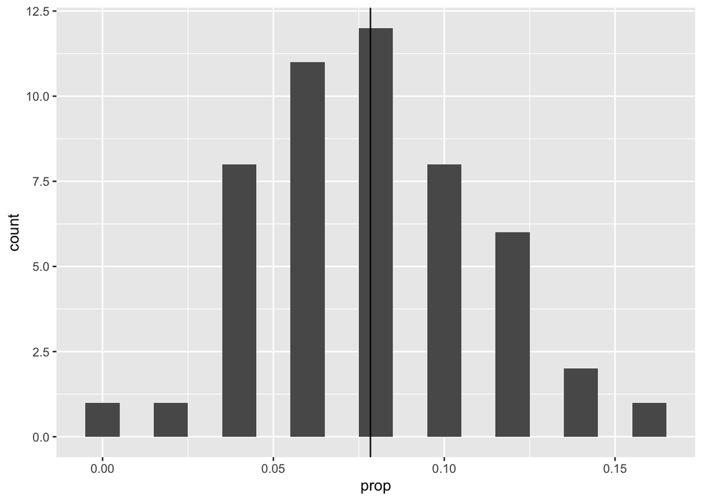

```r
ggplot(female_nobel,
      aes(x = prop)) +
  geom_histogram(binwidth = .01) +
  geom_vline(aes(xintercept = mean(prop)))
```

Q.6)

Q: Explain the **Central Limit Theorem** it in your own words. Be as concise as you can (i.e., use no more than 3-4 sentences) but convince me you really understand the basic idea.

A: As the size increases, the bell shape and the spread of the distribution decreases. This allows the distribution to continue and get close to the tru distribution proportion. The normality of a distribution is in accordance to the sample size. This normality is shown with a tall peak above the rest of the sample size.